# Surface Water

# Quantifying Seasonality

The fundamental question here seems to be, “to what extent is the variability in the data due to seasonal effects, rather than annual differences”? Unfortunately, there aren’t very many data points per station within this data set, and the time period of observation only lasts a few years’ time. This makes disentangling variation in observations for each site difficult–the change in observed data could be due to measurement error, a product of seasonal variation, inter-annual variation, random noise, or the effect of a recent event, or the influence of an unknown covariate!

Given the data constraints, a few different strategies came to mind. For each of them, I tested the method on Temperature, since the right strategy would presumably show a seasonal effect for this analyte, and I had a sense of what probably “should” be happening (it presumably will get warmer in the summer months!).

Without knowing the spatial location of any of the stations, I assumed that the stations would be nearby one another, and subject to (at least roughly) the same weather and insolation patterns— if these stations were far apart, it would be even more difficult to measure the “seasonal component” of each analyte, since the magnitude of seasonal changes could be subject to variables such as latitude and elevation.

## Method 1: Use Linear Regression Model Coefficients to quantify seasonal component, by season

Strategy number 1 is running a regression with terms for each year and for each season, to get a sense of the significance and magnitude of seasonal coefficients while “controlling” for annual differences. Both of these variables were included in a linear regression as “dummy” variables, where categories for year and season were represented numerically as presence-absence for each category. Including the season and year variables in the model this way removes the idea of temporal “trajectory” or sequence, which may not exist, or which may reverse direction mid-way in the time period due to some sort of effect or intervention.

An initial stab at this model also included the sampling station as a variable as well– however, insufficient data for many of the observation sites (on the order of 2-3 observations for the full time period for Temperature, for instance) makes inference about the individual station’s expected deviation from the mean dubious, and virtually none of the sites were statistically significant in the model. Knowing that certain sites group together might be one way to improve this– for instance, if all of the “FE-ET” stations could be considered together, it would likely improve the model’s estimate, and would better disentangle variation due to site-specific conditions rather than seasonality or annual differences.

```r
# Testing out a linear model with temperature
mod <- lm(StandardResult  ~ as.factor(Year)+Season,data=analyte)
summary(mod)
```

```
##
## Call:
## lm(formula = StandardResult ~ as.factor(Year) + Season, data = analyte)
##
## Residuals:
##     Min      1Q  Median      3Q     Max
## -7.8773 -2.1287  0.3849  2.1442  6.9649
##
## Coefficients:
##                   Estimate Std. Error t value Pr(>|t|)
## (Intercept)         5.2510     1.0517   4.993 1.12e-06 ***
## as.factor(Year)16  -2.7057     0.5403  -5.008 1.04e-06 ***
## as.factor(Year)17  -1.7522     0.5108  -3.430 0.000705 ***
## SeasonSpring        2.8963     1.0167   2.849 0.004756 **
## SeasonSummer        3.4076     1.0434   3.266 0.001245 **
## SeasonFall          4.5409     1.1001   4.128 5.00e-05 ***
## ---
## Signif. codes:  0 '***' 0.001 '**' 0.01 '*' 0.05 '.' 0.1 ' ' 1
##
## Residual standard error: 2.758 on 249 degrees of freedom
## Multiple R-squared:  0.2341, Adjusted R-squared:  0.2187
## F-statistic: 15.22 on 5 and 249 DF,  p-value: 4.761e-13
```

```r
linear_model_results<-list() # Create empty list for results to go into
analytes<-unique(sw$StandardAnalyte)
analytes<-analytes[!analytes %in% c("Alkalinity, Total", "DOC", "TOC", "TDS, ratio")] # Each of these are creating problems, so to save time, I'm just going to exclude them from this analysis

for (a in analytes){
  print(a)
  analyte<-sw[StandardAnalyte==a]

  # Run the model for the analyte
  mod <- lm(StandardResult  ~ as.factor(Year)+Season,data=analyte)

# Capture the regression coefficients produced by the model
  analyte_results<-data.table(analyte=a,coef=names(mod$coefficients),est=mod$coefficients,std_error=coef(summary(mod))[, "Std. Error"])

linear_model_results[[a]]<-analyte_results # Add the table of regression coefficients to the list
}
```

```
## [1] "Aluminum, dissolved"
## [1] "Aluminum, total"
## [1] "Arsenic, dissolved"
## [1] "Arsenic, total"
## [1] "Barium, dissolved"
## [1] "Barium, total"
## [1] "Cadmium, dissolved"
## [1] "Cadmium, total"
## [1] "Calcium, dissolved"
## [1] "Calcium, total"
## [1] "Cation-Anion Balance"
## [1] "Chromium, dissolved"
## [1] "Chromium, total"
## [1] "Cobalt, dissolved"
## [1] "Cobalt, total"
```

[output cut: 55 more lines]

```r
linear_model_results<-rbindlist(linear_model_results)
```

```r
linear_model_results[coef=="(Intercept)", intercept:=est]
linear_model_results[,intercept:=min(intercept,na.rm=T),by=analyte]
```

There is some discussion of the number of knots that are appropriate for seasonal land (not water) surface temperature changes in this paper here: http://www.mdpi.com/2072-4292/9/12/1254/pdf; however, it is discussed that the ideal number of knots for their model to represent seasonality (8) may not be appropriate for other applications.

## Fit GAMM with knots for each season and year

Another possible approach is to fit a general additive mixed model, where the long-term time trend and the short-term, periodic seasonal trends are conceptualized by cubic splines.

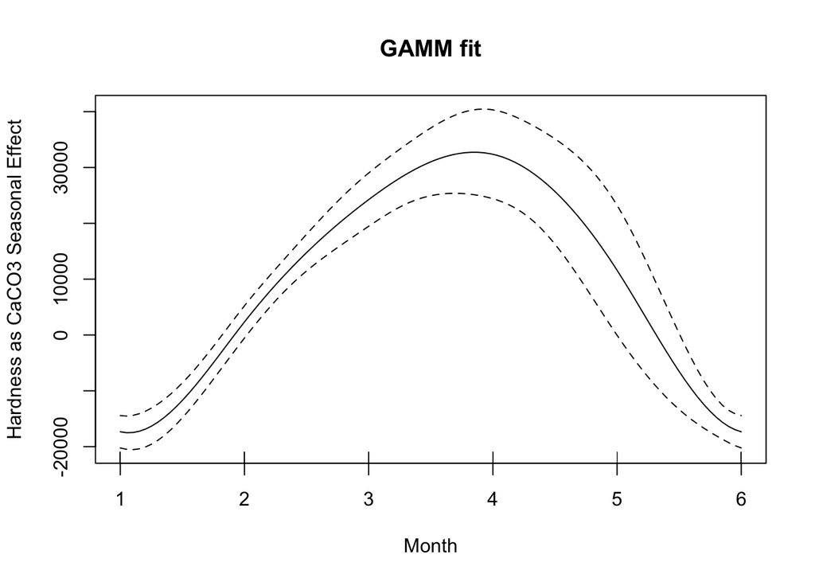

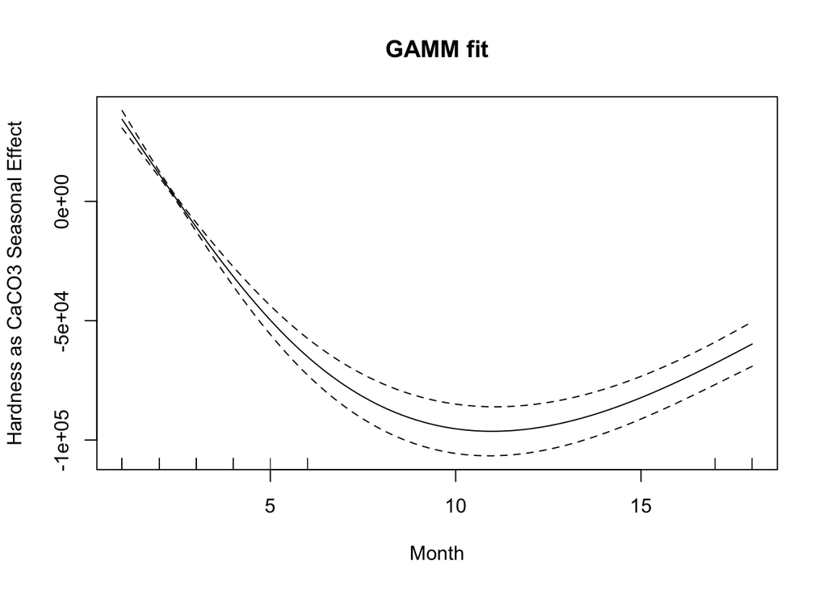

```r
# Pulling from https://www.fromthebottomoftheheap.net/2014/05/09/modelling-seasonal-data-with-gam/
# 1 knot every 6 months, 1 knot for each year of data?
m0 <- mgcv::gamm(StandardResult ~ s(Month, bs = "cc", k = 6) + s(month_index, k = 3) + as.factor(StationName), data = analyte)

plot(m0$gam, scale = 0, main = "GAMM fit", xlab = "Month", ylab = paste0(a," Seasonal Effect"))
```

Let’s try a linear model with a sin and cosine function

```r
mod <- lm(log_obs  ~ sin(2*pi*(month_index/12))+cos(2*pi*(month_index/12))+StationName,data=analyte)
summary(mod)
```

```
##
## Call:
## lm(formula = log_obs ~ sin(2 * pi * (month_index/12)) + cos(2 *
##     pi * (month_index/12)) + StationName, data = analyte)
##
## Residuals:
##      Min       1Q   Median       3Q      Max
## -0.43556 -0.01892  0.01027  0.05163  0.28269
##
## Coefficients:
##                                 Estimate Std. Error t value Pr(>|t|)
## (Intercept)                    11.422397   0.122179  93.489  < 2e-16 ***
## sin(2 * pi * (month_index/12))  0.544552   0.041755  13.042  < 2e-16 ***
## cos(2 * pi * (month_index/12))  0.318764   0.019950  15.978  < 2e-16 ***
## StationNameFE-A31              -0.673425   0.147899  -4.553 1.12e-05 ***
## StationNameFE-A33              -0.640529   0.170334  -3.760 0.000246 ***
## StationNameFE-A35              -0.437117   0.147899  -2.956 0.003648 **
## StationNameFE-A40              -0.245374   0.147899  -1.659 0.099280 .
## StationNameFE-A40A             -0.367472   0.147899  -2.485 0.014115 *
## StationNameFE-A41A             -0.273953   0.147899  -1.852 0.066031 .
## StationNameFE-A55              -0.200132   0.146738  -1.364 0.174735
## StationNameFE-A56              -0.221419   0.123960  -1.786 0.076169 .
## StationNameFE-A64              -0.206893   0.170334  -1.215 0.226493
## StationNameFE-A68               0.002441   0.123056   0.020 0.984204
## StationNameFE-LA3              -0.283854   0.147899  -1.919 0.056932 .
## ---
## Signif. codes:  0 '***' 0.001 '**' 0.01 '*' 0.05 '.' 0.1 ' ' 1
##
## Residual standard error: 0.1195 on 144 degrees of freedom
## Multiple R-squared:  0.9212, Adjusted R-squared:  0.9141
## F-statistic: 129.5 on 13 and 144 DF,  p-value: < 2.2e-16
```

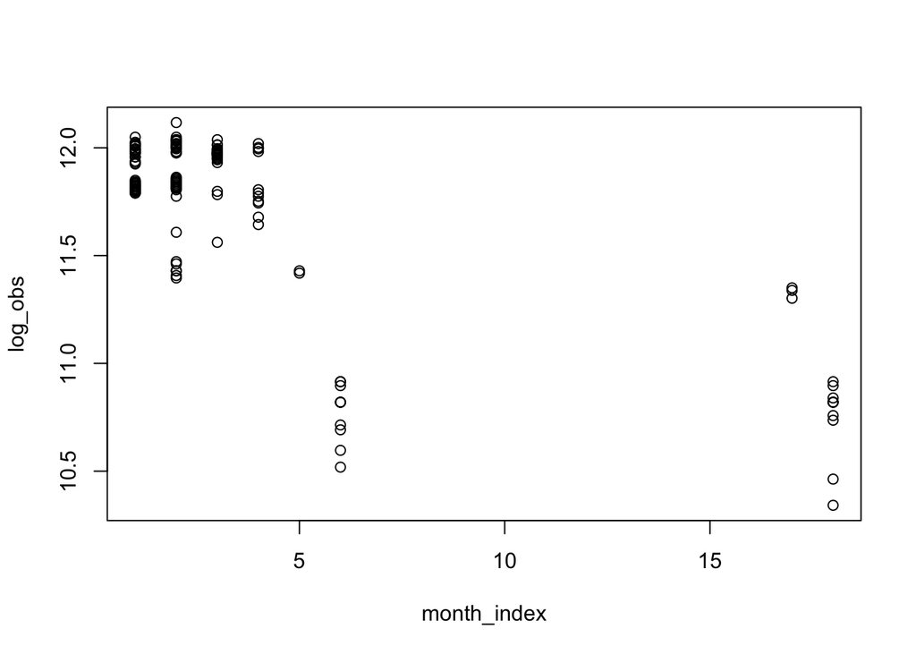

```r
plot(log_obs~month_index,data=analyte)
```

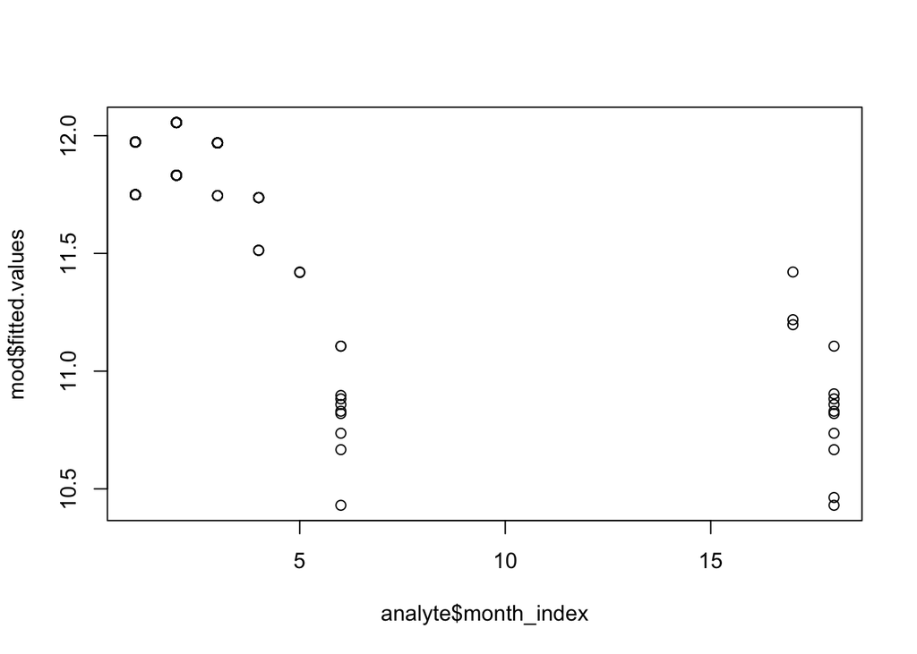

```r
plot(analyte$month_index,mod$fitted.values)
```

```r
mod <- lm(StandardResult  ~ sin(2*pi*(month_index/12))+cos(2*pi*(month_index/12))+StationName+Year,data=analyte)
summary(mod)
```

```
##
## Call:
## lm(formula = StandardResult ~ sin(2 * pi * (month_index/12)) +
##     cos(2 * pi * (month_index/12)) + StationName + Year, data = analyte)
##
## Residuals:
##    Min     1Q Median     3Q    Max
## -46939  -2044   1343   4519  30808
##
## Coefficients:
##                                Estimate Std. Error t value Pr(>|t|)
## (Intercept)                      144660      82107   1.762   0.0802 .
## sin(2 * pi * (month_index/12))    49531       4675  10.594   <2e-16 ***
## cos(2 * pi * (month_index/12))    31886       2293  13.908   <2e-16 ***
## StationNameFE-A31                -26269      15855  -1.657   0.0998 .
## StationNameFE-A33                -23575      18700  -1.261   0.2095
## StationNameFE-A35                -17269      15855  -1.089   0.2779
## StationNameFE-A40                 -8269      15855  -0.522   0.6028
## StationNameFE-A40A               -14269      15855  -0.900   0.3697
## StationNameFE-A41A                -9769      15855  -0.616   0.5388
## StationNameFE-A55                 -7594      16398  -0.463   0.6440
## StationNameFE-A56                -16748      13296  -1.260   0.2099
## StationNameFE-A64                 -7963      18153  -0.439   0.6616
## StationNameFE-A68                 14391      13185   1.091   0.2769
## StationNameFE-LA3                -10269      15855  -0.648   0.5182
## Year                              -3387       5406  -0.627   0.5319
## ---
## Signif. codes:  0 '***' 0.001 '**' 0.01 '*' 0.05 '.' 0.1 ' ' 1
##
## Residual standard error: 12720 on 143 degrees of freedom
## Multiple R-squared:  0.8999, Adjusted R-squared:  0.8901
## F-statistic: 91.79 on 14 and 143 DF,  p-value: < 2.2e-16
```

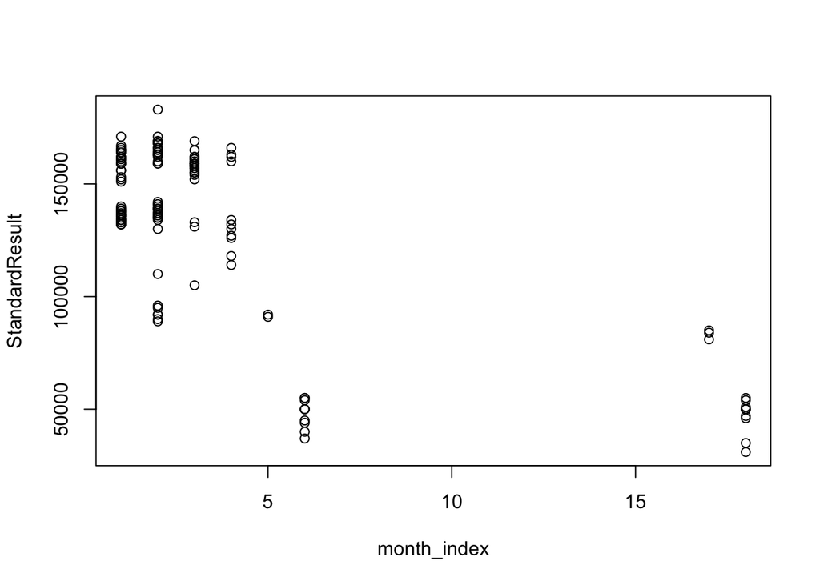

```r
plot(StandardResult~month_index,data=analyte)
lines(mod$fitted.values,analyte$month_index,col=2)
```

```r
analyte[,fitted:=mod$fitted.values]
```

## Generate PDF of results for each Analyte

```r
for ( a in unique(sw$StandardAnalyte)){
  analyte<-sw[StandardAnalyte==a]
pdf(paste0("/Users/stubbsrw/Documents/git_code/stubbs_repo/fe_problems/results/surface_temperature/",a,".pdf"))

  # Generate plot for each Analyte over time, for each station.
  for (s in unique(sw$StationName)){

    p<-ggplot(sw[StandardAnalyte==a & StationName==s],
        aes(x= Date, y=StandardResult, color=Season)) + geom_point(size=4) +
        xlab("Date of Sample") +
        scale_x_date(labels = function(x) format(x, "%b-%y")) +
        ylab(analyte$StandardUnit[1]) +
        ggtitle(paste0(a), subtitle=paste0("Station ",s)) + theme_bw()  +
        scale_colour_manual(name = "Seasons",values = SeasonColors, drop=F) +
        geom_hline(yintercept = sw[StandardAnalyte==a & StationName==s]$mean_concentration_analyte_station[1]) +
        annotate("text", min(analyte$Date),
                 sw[StandardAnalyte==a & StationName==s]$mean_concentration_analyte_station[1],
                 vjust = -1, label = "Mean")

    print(p) # Print it to the PDF
  }
  dev.off() # Close PDF for each
}
```